# RESULTS for ‘same data different analysts’ project, ‘Many EcoEvo Analysts’ dataset

Luke J. Eberhart-Phillips and Martin Bulla

2020-09-07 09:51:20

We found consistent treatment effects across all response variables (Figure R) that were independent of the model specifications (see extended [Tables TE, WE and BE](https://www.dropbox.com/sh/fmyp12uu45qruwo/AACkHcZAZvqYL0Z0Z1ZIShF1a?dl=0) with all specified models and standardized effect sizes). In the nests where most chicks were added, which also generally corresponds to the nests with the most chicks at the day 14 (the day of chick measurement), chicks died the most (estimate [95%CI]: 0.236 [0.172 - 0.302] dead chicks per added chick), had smaller tarsus (-0.063 [-0.074 to -0.051] mm per added chick), lower body mass (-0.182 [-0.213 to -0.153] g per added chick), and were the leanest, i.e. had the lowest body mass index (-0.00037 [-0.00045 to -0.00029] per added chick; Figure R, Tables M, T, W, B). The results were similar even when we controlled for nest pairs (Figure EP and Tables [TEP, WEP, BEP](https://www.dropbox.com/sh/fmyp12uu45qruwo/AACkHcZAZvqYL0Z0Z1ZIShF1a?dl=0)).

Treatment in interaction with sex did not improve the model fit (see Tables Tc, Wc, Bc below) and the simplest models (model “a” in Tables T, W, B performed the best of all (also exploratory) models, i.e. no other model had delta AIC smaller than 5 ([predefined a priori](https://raw.githack.com/MartinBulla/many_analysts/master/MS/Protocol.html)), and even not smaller than 2 (see extended [Tables TE, WE, BE](https://www.dropbox.com/sh/fmyp12uu45qruwo/AACkHcZAZvqYL0Z0Z1ZIShF1a?dl=0) with all specified models and standardized effect sizes).

Code to load tools and prepare data:

```r
# define constants
reml = TRUE # models fitted with REML (TRUE) or ML (FALSE)
nsim <- 5000 # number of simulations for predictions

# load/install packages
    using<-function(...) {
        libs<-unlist(list(...))
        req<-unlist(lapply(libs,require,character.only=TRUE))
        need<-libs[req==FALSE]
        if(length(need)>0){
            install.packages(need)
            lapply(need,require,character.only=TRUE)
        }
    }
    packages = c('anytime','arm','data.table', 'effects', 'foreach', 'ggplot2', 'ggthemes', 'glue',  'grid', 'gridExtra', 'here', 'htmlTable', 'lattice', 'lubridate', 'magrittr', 'multcomp', 'performance','plyr','raster','stringr','zoo', 'gt', 'tidyverse', 'ggpubr')
    sapply(packages, function(x) suppressPackageStartupMessages(using(x)) )

# colors
    f_col = "#FCB42C"
    m_col = "#535F7C"
    u_col = "#5eab2b"

# Customized ggplot theme
    theme_MB = theme(
              axis.line=element_blank(),
              #axis.line = element_line(colour="grey70", size=0.25),
              axis.title = element_text(size=7, colour="grey30"),
              axis.title.y = element_text(vjust=3.5),
              axis.title.x = element_text(vjust=1),
              axis.text=element_text(size=6),#, vjust = 0.5, hjust=1),# margin=units(0.5,"mm")),
              axis.ticks.length=unit(0.5,"mm"),
              axis.ticks = element_line(colour = "grey70"),
              #axis.ticks.margin,

              strip.text.x = element_text(size = 6, color="grey30",  margin=margin(1,1,1,1,"mm")), #grey50
              strip.background = element_rect(fill="grey99",colour="grey70", size=0.25),
                #strip.background = element_blank(),
                #strip.text = element_blank(),
              panel.spacing = unit(0, "mm"),
              panel.background=element_blank(),
                #panel.border=element_blank(),
              panel.border = element_rect(colour="grey70", size=0.25, fill = NA),
              panel.grid = element_blank(),
              legend.text=element_text(size=6),
              legend.title=element_text(size=7)
              )

# functions
    get_legend<-function(myggplot){
      tmp <- ggplot_gtable(ggplot_build(myggplot))
      leg <- which(sapply(tmp$grobs, function(x) x$name) == "guide-box")
      legend <- tmp$grobs[[leg]]
      return(legend)
    }

  # model output function
      m_out = function(name = "define", model = m, round_ = 3, nsim = 5000, aic = TRUE, save_sim = FALSE, N = NA){
      bsim <- sim(model, n.sim=nsim)
        if(save_sim!=FALSE){save(bsim, file = paste0(save_sim, name,'.RData'))}
       v = apply(bsim@fixef, 2, quantile, prob=c(0.5))
       ci = apply(bsim@fixef, 2, quantile, prob=c(0.025,0.975))
       oi=data.frame(model = name,type='fixed',effect=rownames(coef(summary(model))),estimate=v, lwr=ci[1,], upr=ci[2,])
          rownames(oi) = NULL
          oi$estimate_r=round(oi$estimate,round_)
          oi$lwr_r=round(oi$lwr,round_)
          oi$upr_r=round(oi$upr,round_)
      oii=oi[c('model','type',"effect", "estimate_r","lwr_r",'upr_r')]

       l=data.frame(summary(model)$varcor)
       l = l[is.na(l$var2),]
       l$var1 = ifelse(is.na(l$var1),"",l$var1)
       l$pred = paste(l$grp,l$var1)

       q050={}
       q025={}
       q975={}
       pred={}

       # variance of random effects
       for (ran in names(bsim@ranef)) {
         ran_type = l$var1[l$grp == ran]
         for(i in ran_type){
          q050=c(q050,quantile(apply(bsim@ranef[[ran]][,,ran_type], 1, var), prob=c(0.5)))
          q025=c(q025,quantile(apply(bsim@ranef[[ran]][,,ran_type], 1, var), prob=c(0.025)))
          q975=c(q975,quantile(apply(bsim@ranef[[ran]][,,ran_type], 1, var), prob=c(0.975)))
          pred= c(pred,paste(ran, i))
          }
         }
       # residual variance
       q050=c(q050,quantile(bsim@sigma^2, prob=c(0.5)))
       q025=c(q025,quantile(bsim@sigma^2, prob=c(0.025)))
       q975=c(q975,quantile(bsim@sigma^2, prob=c(0.975)))
       pred= c(pred,'Residual')

       ri=data.frame(model = name,type='random',effect=pred, estimate_r=round(100*q050/sum(q050)), lwr_r=round(100*q025/sum(q025)), upr_r=round(100*q975/sum(q975)))
         rx = ri[ri$effect == 'Residual',]
         if(rx$lwr_r>rx$upr_r){ri$lwr_r[ri$effect == 'Residual'] = rx$upr_r; ri$upr_r[ri$effect == 'Residual'] = rx$lwr_r}
         ri$estimate_r = paste0(ri$estimate_r,'%')
         ri$lwr_r = paste0(ri$lwr_r,'%')
         ri$upr_r = paste0(ri$upr_r,'%')

      x = rbind(oii,ri)
        x$N = ""
        x$N[1] = N
        if (aic == TRUE){
            x$AIC = ""
            x$AIC[1]=AIC(update(model,REML = FALSE))
            x$delta = ""
            x$prob = ""
            x$ER = ""
        }
        x$R2_mar = ""
        x$R2_con = ""
        x$R2_mar [1]= invisible({capture.output({r2_nakagawa(model)$R2_marginal})})
        x$R2_con [1]= invisible({capture.output({r2_nakagawa(model)$R2_conditional})})
        return(x)
      }

  # model assumption function
      m_ass = function(name = 'define', mo = m0, dat = d, fixed = NULL, categ = NULL, trans = NULL, spatial = TRUE, temporal = TRUE, PNG = TRUE, outdir = 'outdir'){
       l=data.frame(summary(mo)$varcor)
       l = l[is.na(l$var2),]
       if(PNG == TRUE){
        png(paste(outdir,name, ".png", sep=""), width=6,height=9,units="in",res=600)
         }else{dev.new(width=6,height=9)}

       n = nrow(l)-1+length(fixed)+length(categ) + 4 + if(temporal==TRUE){1}else{0} + if(spatial==TRUE){1}else{0}
       par(mfrow=c(ceiling(n/3),3))

       scatter.smooth(fitted(mo),resid(mo),col='grey');abline(h=0, lty=2, col ='red')
       scatter.smooth(fitted(mo),sqrt(abs(resid(mo))), col='grey')
       qqnorm(resid(mo), main=list("Normal Q-Q Plot: residuals", cex=0.8),col='grey');qqline(resid(mo))
       #unique(l$grp[l$grp!="Residual"])
       for(i in unique(l$grp[l$grp!="Residual"])){
        #i = "mean_year"
        ll=ranef(mo)[names(ranef(mo))==i][[1]]
        if(ncol(ll)==1){
         qqnorm(ll[,1], main = paste(i,names(ll)[1]),col='grey');qqline(ll[,1], col ='red')
         }else{
          qqnorm(ll[,1], main = paste(i,names(ll)[1]),col='grey');qqline(ll[,1], col ='red')
          qqnorm(ll[,2], main = paste(i,names(ll)[2]),col='grey');qqline(ll[,2], col ='red')
         }
        }

       # variables
       scatter={}
       for (i in rownames(summary(mo)$coef)) {
            #i = "lat_abs"
          j=sub("\\).*", "", sub(".*\\(", "",i))
          scatter[length(scatter)+1]=j
        }
        x = data.frame(scatter=unique(scatter)[2:length(unique(scatter))],
                        log_ = grepl("log",rownames(summary(mo)$coef)[2:length(unique(scatter))]), stringsAsFactors = FALSE)
        for (i in 1:length(fixed)){
            jj =fixed[i]
            variable=dat[, ..jj][[1]]
            if(trans[i]=='log'){
            scatter.smooth(resid(mo)~log(variable),xlab=paste('log(',jj,')',sep=''), col = 'grey');abline(h=0, lwd=1, lty = 2, col ='red')
            }else if(trans[i]=='abs'){
            scatter.smooth(resid(mo)~abs(variable),xlab=paste('abs(',jj,')',sep=''), col = 'grey');abline(h=0, lwd=1, lty = 2, col ='red')
            }else{
            scatter.smooth(resid(mo)~variable,xlab=jj,col = 'grey');abline(h=0, lwd=1, lty = 2, col ='red')
          }
         }

        if(length(categ)>0){
          for(i in categ){
             variable=dat[, ..i][[1]]
              boxplot(resid(mo)~variable, medcol='grey', whiskcol='grey', staplecol='grey', boxcol='grey', outcol='grey');abline(h=0, lty=3, lwd=1, col = 'red')
             }
        }

        if(temporal == TRUE){
            acf(resid(mo), type="p", main=list("Temporal autocorrelation:\npartial series residual",cex=0.8))
            }
        if(spatial == TRUE){
        spdata=data.frame(resid=resid(mo), x=dat$Longitude, y=dat$Latitude)
            spdata$col=ifelse(spdata$resid<0,rgb(83,95,124,100, maxColorValue = 255),ifelse(spdata$resid>0,rgb(253,184,19,100, maxColorValue = 255), 'red'))
            #cex_=c(1,2,3,3.5,4)
            cex_=c(1,1.5,2,2.5,3)
            spdata$cex=as.character(cut(abs(spdata$resid), 5, labels=cex_))
          plot(spdata$x, spdata$y,col=spdata$col, cex=as.numeric(spdata$cex), pch= 16, main=list('Spatial distribution of residuals', cex=0.8))
            legend("topleft", pch=16, legend=c('>0','<0'), ,col=c(rgb(83,95,124,100, maxColorValue = 255),rgb(253,184,19,100, maxColorValue = 255)), cex=0.8)
          plot(spdata$x[spdata$resid<0], spdata$y[spdata$resid<0],col=spdata$col[spdata$resid<0], cex=as.numeric(spdata$cex[spdata$resid<0]), pch= 16, main=list('Spatial distribution of residuals (<0)', cex=0.8))
          plot(spdata$x[spdata$resid>=0], spdata$y[spdata$resid>=0],col=spdata$col[spdata$resid>=0], cex=as.numeric(spdata$cex[spdata$resid>=0]), pch= 16, main=list('Spatial distribution of residuals (>=0)', cex=0.8))
            }

       mtext(paste(slot(mo,"call")[1],'(',slot(mo,"call")[2],sep=''), side = 3, line = -1, cex=0.7,outer = TRUE)
      if(PNG==TRUE){dev.off()}
      }
```

```r
# load data
a = fread('../Data/blue_tit_data.csv')
    # a = read.csv(here::here("Data/blue_tit_data.csv"), stringsAsFactors = FALSE)
    setnames(a, old = 'genetic_dad_ring_(WP_or_EP)', new = 'genetic_dad')

    a = a[net_rearing_manipulation != ".", .(rear_nest_breed_ID, hatch_year, rear_nest_OH, chick_sex_molec, hatch_mom_Ring, genetic_dad, day_14_weight, day_14_tarsus_length,
        rear_nest_trt, net_rearing_manipulation, rear_Cs_at_start_of_rearing, d14_rear_nest_brood_size,  d0_hatch_nest_brood_size, rear_d0_rear_nest_brood_size,day14_measurer, rear_area)]

# 203455 nest has one chicks with different year for when the eggs began to hatch in the nest in which the chick was reared. 1 = April 1., we assign the same year as is the year for the remaining chicks
    a[rear_nest_breed_ID == '203455', hatch_year := 2003]

# define NAs and column and variable definitions
    a[hatch_mom_Ring %in% ".", hatch_mom_Ring := NA]
    a[genetic_dad %in% ".", genetic_dad := NA]
    a[, rear_Cs_at_start_of_rearing := as.numeric(rear_Cs_at_start_of_rearing)]
    a[, net_rearing_manipulation := as.numeric(net_rearing_manipulation)]
    a[, d14_rear_nest_brood_size := as.numeric(d14_rear_nest_brood_size)]
    a[, d0_hatch_nest_brood_size := as.numeric(d0_hatch_nest_brood_size)]
    a[, rear_d0_rear_nest_brood_size := as.numeric(rear_d0_rear_nest_brood_size)]
    a[chick_sex_molec %in% ".", chick_sex_molec := "u"]
    a[chick_sex_molec %in% "1", chick_sex_molec := "f"]
    a[chick_sex_molec %in% "2", chick_sex_molec := "m"]
    a[rear_nest_trt %in% "5", treatment := "increased"]
    a[rear_nest_trt %in% "6", treatment := "reduced"]
    a[rear_nest_trt %in% "7", treatment := "constant"]

# compute  variables
    a[, change_chick_n := rear_Cs_at_start_of_rearing-d14_rear_nest_brood_size]
    a[, rear_nest_OH_l :=  rear_nest_OH - min(rear_nest_OH), by = hatch_year] # day when first nest hatch in a given year is zero day of the season
    a[, net_rearing_manipulation_factor := as.factor(net_rearing_manipulation)]
    a[, prop_change_in_brood_size := net_rearing_manipulation/d0_hatch_nest_brood_size]
    # sex ration at day 14
        a[chick_sex_molec == 'm', sex := 1]
        a[chick_sex_molec == 'f', sex := 0]
        a[chick_sex_molec == 'u', sex := 0.5]
        a[, brood_sex_ratio := sum(sex)/length(sex), by = rear_nest_breed_ID]
    # body mass index
        a[, body_mass_index := day_14_weight/day_14_tarsus_length^2]
# dataset for chick mortality
    mmo = a[complete.cases(a),.(change_chick_n, net_rearing_manipulation, d14_rear_nest_brood_size, brood_sex_ratio, day14_measurer, rear_area, rear_nest_OH_l, hatch_year,rear_nest_breed_ID)]
    mou = unique(mmo)
    nrow(mou)
    length(unique(mmo$rear_nest_breed_ID))
    mou[, net_rearing_manipulation_factor := as.factor(net_rearing_manipulation)]

    reml = TRUE

# dataset for paired plots
    BT_data <- read.csv(file = "../Data/blue_tit_data.csv", stringsAsFactors = FALSE)
   BT_data_tidy <-
  BT_data %>%
  # select variables of interest
  dplyr::select(chick_ring_number, hatch_year, hatch_nest_breed_ID, rear_nest_breed_ID, rear_area, hatch_mom_Ring,
         genetic_dad_ring_.WP_or_EP., hatch_nest_OH, rear_nest_OH, d0_hatch_nest_brood_size, rear_d0_rear_nest_brood_size,
         rear_nest_trt, net_rearing_manipulation, rear_Cs_at_start_of_rearing, d14_rear_nest_brood_size,
         day_14_tarsus_length, day_14_weight, day14_measurer, chick_sex_molec, number_chicks_fledged_from_rear_nest) %>%
  # rename the genetic dad vaiable
  dplyr::rename(genetic_dad_ring = genetic_dad_ring_.WP_or_EP.,
         d0_rear_nest_brood_size = rear_d0_rear_nest_brood_size) %>%
  # replace all "." with NA in factor variables
  dplyr::mutate(chick_sex_molec = as.factor(ifelse(chick_sex_molec == ".", NA,
                                ifelse(chick_sex_molec == "1", "Female", "Male"))),
         chick_BMI = day_14_weight/(day_14_tarsus_length^2)) %>%
  dplyr::mutate_at(c("hatch_year", "hatch_nest_breed_ID", "rear_nest_breed_ID",
              "day14_measurer", "rear_nest_trt", "hatch_mom_Ring",
              "genetic_dad_ring", "chick_ring_number", "rear_area"),
            as.factor) %>%
  dplyr::mutate_if(is.factor, list(~dplyr::na_if(., "."))) %>%
  dplyr::mutate_at(c("net_rearing_manipulation", "rear_Cs_at_start_of_rearing", "d0_hatch_nest_brood_size",
              "d0_rear_nest_brood_size", "number_chicks_fledged_from_rear_nest"),
            as.numeric) %>%
  # re-name the treatment groups
  dplyr::mutate(rear_nest_trt =
           as.factor(ifelse(rear_nest_trt == "5", "increase",
                        ifelse(rear_nest_trt == "6", "decrease", "control")))) %>%
  dplyr::mutate(prop_change_in_brood_size = net_rearing_manipulation/d0_hatch_nest_brood_size,
                change_chick_n = rear_Cs_at_start_of_rearing - d14_rear_nest_brood_size)

BT_nest_pairs <-
  BT_data_tidy %>%
  dplyr::group_by(chick_ring_number) %>%
  dplyr::mutate_at(c("hatch_nest_breed_ID", "rear_nest_breed_ID"), as.character) %>%
  dplyr::mutate_at(c("hatch_nest_breed_ID", "rear_nest_breed_ID"), as.numeric) %>%
  dplyr::summarise(pair_ID_min = min(hatch_nest_breed_ID, rear_nest_breed_ID),
            pair_ID_max = max(hatch_nest_breed_ID, rear_nest_breed_ID)) %>%
  dplyr::left_join(BT_data_tidy, ., by = "chick_ring_number") %>%
  dplyr::select(hatch_nest_breed_ID, rear_nest_breed_ID, d0_hatch_nest_brood_size,
         d0_rear_nest_brood_size, rear_nest_trt, net_rearing_manipulation,
         rear_Cs_at_start_of_rearing, pair_ID_min, pair_ID_max) %>%
  dplyr::distinct() %>%
  dplyr::filter(pair_ID_min != pair_ID_max) %>%
  dplyr::mutate(pair_ID = paste(pair_ID_min, pair_ID_max, sep = "_")) %>%
  dplyr::select(hatch_nest_breed_ID, pair_ID)

BT_data_tidy <-
  BT_data_tidy %>%
  dplyr::left_join(., BT_nest_pairs, by = "hatch_nest_breed_ID")

morphometric_summaries <-
  BT_data_tidy %>%
  dplyr::mutate(day_14_BMI = day_14_weight/(day_14_tarsus_length^2)) %>%
  dplyr::group_by(pair_ID, rear_nest_trt) %>%
  dplyr::summarise(mean_tarsus = mean(day_14_tarsus_length, na.rm = TRUE),
            median_tarsus = median(day_14_tarsus_length, na.rm = TRUE),
            sd_tarsus = sd(day_14_tarsus_length, na.rm = TRUE),
            se_tarsus = sd(day_14_tarsus_length, na.rm = TRUE)/sqrt(n()),
            mean_mass = mean(day_14_weight, na.rm = TRUE),
            median_mass = median(day_14_weight, na.rm = TRUE),
            sd_mass = sd(day_14_weight, na.rm = TRUE),
            se_mass = sd(day_14_weight, na.rm = TRUE)/sqrt(n()),
            mean_BMI = mean(day_14_BMI, na.rm = TRUE),
            median_BMI = median(day_14_BMI, na.rm = TRUE),
            sd_BMI = sd(day_14_BMI, na.rm = TRUE),
            se_BMI = sd(day_14_BMI, na.rm = TRUE)/sqrt(n()),
            change_chick_n = change_chick_n) %>%
  dplyr::distinct() %>%
  dplyr::filter(rear_nest_trt != "control") %>%
  tidyr::pivot_wider(names_from = rear_nest_trt,
                     values_fn = list(mean_tarsus = mean,
                                      median_tarsus = mean,
                                      sd_tarsus = mean,
                                      se_tarsus = mean,
                                      mean_mass = mean,
                                      median_mass = mean,
                                      sd_mass = mean,
                                      se_mass = mean,
                                      mean_BMI = mean,
                                      median_BMI = mean,
                                      sd_BMI = mean,
                                      se_BMI = mean,
                                      change_chick_n = mean),
              values_from = c(mean_tarsus, median_tarsus, sd_tarsus, se_tarsus,
                              mean_mass, median_mass, sd_mass, se_mass,
                              mean_BMI, median_BMI, sd_BMI, se_BMI,
                              change_chick_n)) %>%
  na.omit
```

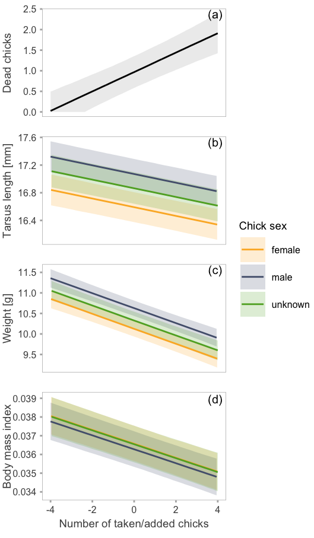

```r
# limit data to available cases
      dtg = a[complete.cases(a),.(day_14_tarsus_length, day_14_weight, body_mass_index,  net_rearing_manipulation, net_rearing_manipulation_factor, d14_rear_nest_brood_size, chick_sex_molec, brood_sex_ratio, day14_measurer, rear_area, rear_nest_OH_l, hatch_year,rear_nest_breed_ID, hatch_mom_Ring, genetic_dad)]
# predictions
        # mortality
            m = lmer(change_chick_n ~ net_rearing_manipulation  +
                      brood_sex_ratio +
                      (1|day14_measurer) +
                      (1|rear_area) +
                      (1|rear_nest_OH_l) + (1|hatch_year),
                      data = mou, REML = reml
                 )
            bsim <- sim(m, n.sim=nsim)

            # coefficients
                v = apply(bsim@fixef, 2, quantile, prob=c(0.5))
                ci = apply(bsim@fixef, 2, quantile, prob=c(0.025, 0.975))

            # values to predict for
                newD=data.frame(net_rearing_manipulation = seq(min(mou$net_rearing_manipulation), max(mou$net_rearing_manipulation), length.out = 300), chick_sex_molec = c('m','f','u'), brood_sex_ratio = mean(mou$brood_sex_ratio))

            # exactly the model which was used has to be specified here
                X <- model.matrix(~ net_rearing_manipulation +
                        brood_sex_ratio ,data=newD)

            # calculate predicted values and creditability intervals
                newD$pred <-(X%*%v)
                predmatrix <- matrix(nrow=nrow(newD), ncol=nsim)
                for(i in 1:nsim) predmatrix[,i] <- (X%*%bsim@fixef[i,])
                    predmatrix[predmatrix < 0] <- 0
                    newD$lwr <- apply(predmatrix, 1, quantile, prob=0.025)
                    newD$upr <- apply(predmatrix, 1, quantile, prob=0.975)
                    newD$pred <- apply(predmatrix, 1, quantile, prob=0.5)
            pm=newD

        # tarsus
            m=  lmer(day_14_tarsus_length ~
                    net_rearing_manipulation +
                    chick_sex_molec +
                    brood_sex_ratio +
                    (1|day14_measurer) + (1|rear_area) +
                    (1|rear_nest_OH_l) + (1|hatch_year)  +
                    (1|rear_nest_breed_ID) +
                    (1|hatch_mom_Ring) + (1|genetic_dad),
                    data = dtg, REML = reml
                    )

            bsim <- sim(m, n.sim=nsim)

            # coefficients
                v = apply(bsim@fixef, 2, quantile, prob=c(0.5))
                ci = apply(bsim@fixef, 2, quantile, prob=c(0.025, 0.975))

            # values to predict for
                newD=data.frame(net_rearing_manipulation = seq(min(dtg$net_rearing_manipulation), max(dtg$net_rearing_manipulation), length.out = 300), chick_sex_molec = c('m','f','u'), brood_sex_ratio = mean(dtg$brood_sex_ratio))

            # exactly the model which was used has to be specified here
                X <- model.matrix(~ net_rearing_manipulation +
                        chick_sex_molec +
                        brood_sex_ratio ,data=newD)

            # calculate predicted values and creditability intervals
                newD$pred <-(X%*%v)
                predmatrix <- matrix(nrow=nrow(newD), ncol=nsim)
                for(i in 1:nsim) predmatrix[,i] <- (X%*%bsim@fixef[i,])
                    predmatrix[predmatrix < 0] <- 0
                    newD$lwr <- apply(predmatrix, 1, quantile, prob=0.025)
                    newD$upr <- apply(predmatrix, 1, quantile, prob=0.975)
                    newD$pred <- apply(predmatrix, 1, quantile, prob=0.5)
            pt=newD
            pt$chick_sex_molec = ifelse(pt$chick_sex_molec == 'u', "unknown", ifelse(pt$chick_sex_molec =='f', 'female', 'male'))
        # weight
            m=  lmer(day_14_weight ~
                    net_rearing_manipulation +
                    chick_sex_molec +
                    brood_sex_ratio +
                    (1|day14_measurer) + (1|rear_area) +
                    (1|rear_nest_OH_l) + (1|hatch_year)  +
                    (1|rear_nest_breed_ID) +
                    (1|hatch_mom_Ring) + (1|genetic_dad),
                    data = dtg, REML = reml
                    )

            bsim <- sim(m, n.sim=nsim)

            # coefficients
                v = apply(bsim@fixef, 2, quantile, prob=c(0.5))
                ci = apply(bsim@fixef, 2, quantile, prob=c(0.025, 0.975))

            # values to predict for
                newD=data.frame(net_rearing_manipulation = seq(min(dtg$net_rearing_manipulation), max(dtg$net_rearing_manipulation), length.out = 300), chick_sex_molec = c('m','f','u'), brood_sex_ratio = mean(dtg$brood_sex_ratio))

            # exactly the model which was used has to be specified here
                X <- model.matrix(~ net_rearing_manipulation +
                        chick_sex_molec +
                        brood_sex_ratio ,data=newD)

            # calculate predicted values and creditability intervals
                newD$pred <-(X%*%v)
                predmatrix <- matrix(nrow=nrow(newD), ncol=nsim)
                for(i in 1:nsim) predmatrix[,i] <- (X%*%bsim@fixef[i,])
                    predmatrix[predmatrix < 0] <- 0
                    newD$lwr <- apply(predmatrix, 1, quantile, prob=0.025)
                    newD$upr <- apply(predmatrix, 1, quantile, prob=0.975)
                    newD$pred <- apply(predmatrix, 1, quantile, prob=0.5)
            pw=newD
            pw$chick_sex_molec = ifelse(pw$chick_sex_molec == 'u', "unknown", ifelse(pw$chick_sex_molec =='f', 'female', 'male'))
        # BMI
            m=  lmer(body_mass_index ~
                    net_rearing_manipulation +
                    chick_sex_molec +
                    brood_sex_ratio +
                    (1|day14_measurer) + (1|rear_area) +
                    (1|rear_nest_OH_l) + (1|hatch_year)  +
                    (1|rear_nest_breed_ID) +
                    (1|hatch_mom_Ring) + (1|genetic_dad),
                    data = dtg, REML = reml
                    )

            nsim <- 5000
            bsim <- sim(m, n.sim=nsim)

            # coefficients
                v = apply(bsim@fixef, 2, quantile, prob=c(0.5))
                ci = apply(bsim@fixef, 2, quantile, prob=c(0.025, 0.975))

            # values to predict for
                newD=data.frame(net_rearing_manipulation = seq(min(dtg$net_rearing_manipulation), max(dtg$net_rearing_manipulation), length.out = 300), chick_sex_molec = c('m','f','u'), brood_sex_ratio = mean(dtg$brood_sex_ratio))

            # exactly the model which was used has to be specified here
                X <- model.matrix(~ net_rearing_manipulation +
                        chick_sex_molec +
                        brood_sex_ratio ,data=newD)

            # calculate predicted values and creditability intervals
                newD$pred <-(X%*%v)
                predmatrix <- matrix(nrow=nrow(newD), ncol=nsim)
                for(i in 1:nsim) predmatrix[,i] <- (X%*%bsim@fixef[i,])
                    predmatrix[predmatrix < 0] <- 0
                    newD$lwr <- apply(predmatrix, 1, quantile, prob=0.025)
                    newD$upr <- apply(predmatrix, 1, quantile, prob=0.975)
                    newD$pred <- apply(predmatrix, 1, quantile, prob=0.5)
            pb=newD
            pb$chick_sex_molec = ifelse(pb$chick_sex_molec == 'u', "unknown", ifelse(pb$chick_sex_molec =='f', 'female', 'male'))
    # prepare plots
        ggm = ggplot(pm, aes(x = net_rearing_manipulation, y = pred))  +
            geom_ribbon(aes(ymin=lwr, ymax=upr, x=net_rearing_manipulation), alpha = 0.1, show.legend = NA)+
            geom_line() +
            labs(x = 'Number of taken/added chicks', y = 'Dead chicks', tag = '(a)')  +
            theme_bw() + theme_MB +
            theme(  legend.position="none",
                    axis.title.x=element_blank(),
                    axis.text.x=element_blank(),
                    axis.ticks.x=element_blank(),
                     plot.tag.position = c(0.95, 0.95),
                    plot.tag = element_text(size = 7.5))

        ggt = ggplot(pt, aes(x = net_rearing_manipulation, y = pred))  +
            geom_ribbon(aes(ymin=lwr, ymax=upr, x=net_rearing_manipulation, fill = chick_sex_molec), alpha = 0.2, show.legend = NA)+
            geom_line(aes(col =chick_sex_molec)) +
            labs(x = 'Number of taken/added chicks', y = 'Tarsus length [mm]', tag = '(b)', fill = 'Chick sex', col = 'Chick sex')+
            scale_fill_manual(labels = c("female", "male", 'unknown'), values = c(f_col, m_col, u_col))+
            scale_color_manual(labels = c("female", "male", 'unknown'), values = c(f_col, m_col, u_col))+
            theme_bw() + theme_MB +
            theme(  axis.title.x=element_blank(),
                    axis.text.x=element_blank(),
                    axis.ticks.x=element_blank(),
                    plot.tag.position = c(0.95, 0.95),
                    plot.tag = element_text(size = 7.5))
        legend = get_legend(ggt)
        ggt = ggt + theme(legend.position="none")

        ggw = ggplot(pw, aes(x = net_rearing_manipulation, y = pred))  +
            geom_ribbon(aes(ymin=lwr, ymax=upr, x=net_rearing_manipulation, fill = chick_sex_molec), alpha = 0.2, show.legend = NA)+
            geom_line(aes(col =chick_sex_molec)) +
            labs(x = 'Number of taken/added chicks', y = 'Weight [g]', tag = '(c)')  +
            scale_fill_manual(labels = c("female", "male", 'unknown'), values = c(f_col, m_col, u_col))+
            scale_color_manual(labels = c("female", "male", 'unknown'), values = c(f_col, m_col, u_col))+
            theme_bw() + theme_MB +
            theme(  legend.position="none",
                    axis.title.x=element_blank(),
                    axis.text.x=element_blank(),
                    axis.ticks.x=element_blank(),
                     plot.tag.position = c(0.95, 0.95),
                    plot.tag = element_text(size = 7.5))

        ggb = ggplot(pb, aes(x = net_rearing_manipulation, y = pred))  +
            geom_ribbon(aes(ymin=lwr, ymax=upr, x=net_rearing_manipulation, fill = chick_sex_molec), alpha = 0.2, show.legend = NA)+
            geom_line(aes(col =chick_sex_molec)) +
            labs(x = 'Number of taken/added chicks', y = 'Body mass index', tag = '(d)') +
            scale_fill_manual(labels = c("female", "male", 'unknown'), values = c(f_col, m_col, u_col))+
            scale_color_manual(labels = c("female", "male", 'unknown'), values = c(f_col, m_col, u_col))+
            theme_bw() + theme_MB +
            theme(  legend.position="none",
                    #axis.title.y = element_text(margin = margin(t = 0, r = 20, b = 0, l = 0)
                    plot.tag.position = c(0.95, 0.95),
                    plot.tag = element_text(size = 7.5))
    # Figure R - COMBINED MTWB
        g0 <- ggplotGrob(ggm)
        g1 <- ggplotGrob(ggt)
        g2 <- ggplotGrob(ggw)
        g3 <- ggplotGrob(ggb)

        grid.arrange(rbind(g0,g1,g2,g3, size = "first"), legend, ncol = 2, padding = 0, widths =c(3.7, 1.25))
```

#### Figure R | Chick mortality and size according to net change in brood size

Change in chick number between day 0 and day 14 of the experiment (a), tarsus length (b), body mass (c) and body mass index (d) at day 14 of the experiment given the experimental change in chick numbers within given nest (note that 0 indicates no change, i.e. control nests). Lines with shaded polygons indicate model predictions with 95%CI based on the joint posterior distribution of 5,000 simulated values generated by the ‘sim’ function in R (Gelman and Su 2018) from the model outputs (Tables M, Ta, Wa, Ba), while keeping the other predictors constant. Color in b-d indicates molecular sex of the chick (yellow = female, blue = male and green = unknown).

#### Table M | Effect sizes for chick mortality (*Model M*)

```r
m = lmer(change_chick_n ~ net_rearing_manipulation  +
                      brood_sex_ratio +
                      (1|day14_measurer) +
                      (1|rear_area) +
                      (1|rear_nest_OH_l) + (1|hatch_year),
                      data = mou, REML = reml
                 )
o_m = m_out(name = "mortality", model = m, round_ = 3, nsim = 5000, aic = TRUE, N = nrow(mou))
o_m_source_note = paste("N = ", o_m$N[1], "nests, AIC = ", round(as.numeric(o_m$AIC[1], 4), 2), ", Marginal R-squared = ", round(as.numeric(o_m$R2_mar[1], 4), 2), ", Conditional R-squared = ", round(as.numeric(o_m$R2_con[1], 4), 2))
o_m %>%
  mutate(CI_String = ifelse(!is.na(lwr_r),
                     paste0("[",
                     lwr_r, ", ",
                     upr_r, "]"),
                     NA)) %>%
  dplyr::select(type, effect, estimate_r, CI_String) %>%
  gt(groupname_col = "type") %>%
  cols_label(effect = "Effect type",
             estimate_r = "Parameter estimate",
             CI_String = "95% credible interval") %>%
  cols_align(align = "left",
             columns = vars(effect)) %>%
  tab_options(row_group.font.weight = "bold",
              row_group.background.color = "grey",
              table.font.size = 12,
              data_row.padding = 3,
              row_group.padding = 4,
              summary_row.padding = 2,
              column_labels.font.size = 14,
              row_group.font.size = 12,
              table.width = pct(80)) #%>%  tab_source_note(source_note = o_m_source_note)
```

| Effect type | Parameter estimate | 95% credible interval |
| --- | --- | --- |
| fixed |  |  |
| (Intercept) | 0.772 | [0.105, 1.439] |
| net_rearing_manipulation | 0.237 | [0.172, 0.3] |
| brood_sex_ratio | 0.389 | [-0.722, 1.462] |
| random |  |  |
| rear_nest_OH_l (Intercept) | 0% | [0%, 0%] |
| rear_area (Intercept) | 0% | [0%, 0%] |
| day14_measurer (Intercept) | 2% | [0%, 4%] |
| hatch_year (Intercept) | 1% | [0%, 3%] |
| Residual | 97% | [92%, 100%] |

#### Table T | Effect sizes for chick tarsus models

##### a

```r
dtg = a[complete.cases(a),.(day_14_tarsus_length, net_rearing_manipulation, net_rearing_manipulation_factor, d14_rear_nest_brood_size, chick_sex_molec, brood_sex_ratio, day14_measurer, rear_area, rear_nest_OH_l, hatch_year,rear_nest_breed_ID, hatch_mom_Ring, genetic_dad)]

#cor(dtg$d14_rear_nest_brood_size, dtg$net_rearing_manipulation)

mt0g =  lmer(day_14_tarsus_length ~
    net_rearing_manipulation +
    chick_sex_molec +
    brood_sex_ratio +
    (1|day14_measurer) + (1|rear_area) +
    (1|rear_nest_OH_l) + (1|hatch_year)  +
    (1|rear_nest_breed_ID) +
    (1|hatch_mom_Ring) + (1|genetic_dad),
    data = dtg, REML = reml
    )

#plot(allEffects(mt0g))

o_mt0g = m_out(name = "a - net chick", model = mt0g, round_ = 3, nsim = 5000, aic = TRUE, N = 2550)

o_mt0g_source_note = paste("N = ", o_mt0g$N[1], "nests, AIC = ", round(as.numeric(o_mt0g$AIC[1], 4), 2), ", Marginal R-squared = ", round(as.numeric(o_mt0g$R2_mar[1], 4), 2), ", Conditional R-squared = ", round(as.numeric(o_mt0g$R2_con[1], 4), 2))

o_mt0g %>%
  mutate(CI_String = ifelse(!is.na(lwr_r),
                     paste0("[",
                     lwr_r, ", ",
                     upr_r, "]"),
                     NA)) %>%
  dplyr::select(type, effect, estimate_r, CI_String) %>%
  gt(groupname_col = "type") %>%
  cols_label(effect = "Effect type",
             estimate_r = "Parameter estimate",
             CI_String = "95% credible interval") %>%
  cols_align(align = "left",
             columns = vars(effect)) %>%
  tab_options(row_group.font.weight = "bold",
              row_group.background.color = "grey",
              table.font.size = 12,
              data_row.padding = 3,
              row_group.padding = 4,
              summary_row.padding = 2,
              column_labels.font.size = 14,
              row_group.font.size = 12,
              table.width = pct(80)) #%>% tab_source_note(source_note = o_mt0g_source_note)
```

| Effect type | Parameter estimate | 95% credible interval |
| --- | --- | --- |
| fixed |  |  |
| (Intercept) | 16.551 | [16.305, 16.801] |
| net_rearing_manipulation | -0.063 | [-0.074, -0.051] |
| chick_sex_molecm | 0.479 | [0.431, 0.525] |
| chick_sex_molecu | 0.273 | [0.183, 0.364] |
| brood_sex_ratio | 0.074 | [-0.155, 0.31] |
| random |  |  |
| rear_nest_breed_ID (Intercept) | 13% | [13%, 11%] |
| genetic_dad (Intercept) | 10% | [10%, 8%] |
| hatch_mom_Ring (Intercept) | 12% | [12%, 11%] |
| rear_nest_OH_l (Intercept) | 0% | [0%, 0%] |
| rear_area (Intercept) | 1% | [0%, 1%] |
| day14_measurer (Intercept) | 6% | [1%, 19%] |
| hatch_year (Intercept) | 2% | [1%, 4%] |
| Residual | 56% | [45%, 63%] |

##### b

```r
mt14g =  lmer(day_14_tarsus_length ~
    d14_rear_nest_brood_size +
    chick_sex_molec +
    brood_sex_ratio +
    (1|day14_measurer) + (1|rear_area) +
    (1|rear_nest_OH_l) + (1|hatch_year)  +
    (1|rear_nest_breed_ID) + (1|hatch_mom_Ring) + (1|genetic_dad),
    data = dtg, REML = reml
    )

#summary(mt14g)
#summary(glht(mt14g))
# plot(allEffects(mt14g))
o_mt14g  = m_out(name = "b - day 14 chick #", model = mt14g, round_ = 3, nsim = 5000, aic = TRUE, N = 2550)

o_mt14g_source_note = paste("N = ", o_mt14g$N[1], "nests, AIC = ", round(as.numeric(o_mt14g$AIC[1], 4), 2), ", Marginal R-squared = ", round(as.numeric(o_mt14g$R2_mar[1], 4), 2), ", Conditional R-squared = ", round(as.numeric(o_mt14g$R2_con[1], 4), 2))

o_mt14g %>%
  mutate(CI_String = ifelse(!is.na(lwr_r),
                     paste0("[",
                     lwr_r, ", ",
                     upr_r, "]"),
                     NA)) %>%
  dplyr::select(type, effect, estimate_r, CI_String) %>%
  gt(groupname_col = "type") %>%
  cols_label(effect = "Effect type",
             estimate_r = "Parameter estimate",
             CI_String = "95% credible interval") %>%
  cols_align(align = "left",
             columns = vars(effect)) %>%
  tab_options(row_group.font.weight = "bold",
              row_group.background.color = "grey",
              table.font.size = 12,
              data_row.padding = 3,
              row_group.padding = 4,
              summary_row.padding = 2,
              column_labels.font.size = 14,
              column_labels.hidden = TRUE,
              row_group.font.size = 12,
              table.width = pct(80)) #%>% tab_source_note(source_note = o_mt14g_source_note)
```

| fixed |  |  |
| --- | --- | --- |
| (Intercept) | 16.926 | [16.64, 17.213] |
| d14_rear_nest_brood_size | -0.042 | [-0.055, -0.03] |
| chick_sex_molecm | 0.481 | [0.434, 0.527] |
| chick_sex_molecu | 0.259 | [0.165, 0.355] |
| brood_sex_ratio | 0.082 | [-0.161, 0.342] |
| random |  |  |
| rear_nest_breed_ID (Intercept) | 18% | [18%, 15%] |
| genetic_dad (Intercept) | 10% | [10%, 9%] |
| hatch_mom_Ring (Intercept) | 10% | [10%, 8%] |
| rear_nest_OH_l (Intercept) | 0% | [0%, 0%] |
| rear_area (Intercept) | 2% | [1%, 3%] |
| day14_measurer (Intercept) | 6% | [1%, 21%] |
| hatch_year (Intercept) | 2% | [0%, 3%] |
| Residual | 53% | [41%, 60%] |

##### c

```r
mt0gs =  lmer(day_14_tarsus_length ~
    net_rearing_manipulation * chick_sex_molec +
    brood_sex_ratio +
    (1|day14_measurer) + (1|rear_area) +
    (1|rear_nest_OH_l) + (1|hatch_year)  +
    (1|rear_nest_breed_ID)+
    (1|hatch_mom_Ring) + (1|genetic_dad),
    data = dtg, REML = reml
    )

#plot(allEffects(mt0gs))

o_mt0gs = m_out(name = "c - (a) with sex interaction", model = mt0gs, round_ = 3, nsim = 5000, aic = TRUE, N = 2550)

o_mt0gs_source_note = paste("N = ", o_mt0gs$N[1], "nests, AIC = ", round(as.numeric(o_mt0gs$AIC[1], 4), 2), ", Marginal R-squared = ", round(as.numeric(o_mt0gs$R2_mar[1], 4), 2), ", Conditional R-squared = ", round(as.numeric(o_mt0gs$R2_con[1], 4), 2))

o_mt0gs %>%
  mutate(CI_String = ifelse(!is.na(lwr_r),
                     paste0("[",
                     lwr_r, ", ",
                     upr_r, "]"),
                     NA)) %>%
  dplyr::select(type, effect, estimate_r, CI_String) %>%
  gt(groupname_col = "type") %>%
  cols_label(effect = "Effect type",
             estimate_r = "Parameter estimate",
             CI_String = "95% credible interval") %>%
  cols_align(align = "left",
             columns = vars(effect)) %>%
  tab_options(row_group.font.weight = "bold",
              row_group.background.color = "grey",
              table.font.size = 12,
              data_row.padding = 3,
              row_group.padding = 4,
              summary_row.padding = 2,
              column_labels.font.size = 14,
              column_labels.hidden = TRUE,
              row_group.font.size = 12,
              table.width = pct(80)) #%>% tab_source_note(source_note = o_mt0gs_source_note)
```

| fixed |  |  |
| --- | --- | --- |
| (Intercept) | 16.553 | [16.3, 16.802] |
| net_rearing_manipulation | -0.062 | [-0.077, -0.047] |
| chick_sex_molecm | 0.48 | [0.43, 0.527] |
| chick_sex_molecu | 0.271 | [0.18, 0.366] |
| brood_sex_ratio | 0.073 | [-0.16, 0.309] |
| net_rearing_manipulation:chick_sex_molecm | 0 | [-0.017, 0.016] |
| net_rearing_manipulation:chick_sex_molecu | -0.002 | [-0.03, 0.026] |
| random |  |  |
| rear_nest_breed_ID (Intercept) | 13% | [13%, 11%] |
| genetic_dad (Intercept) | 9% | [9%, 8%] |
| hatch_mom_Ring (Intercept) | 12% | [12%, 11%] |
| rear_nest_OH_l (Intercept) | 0% | [0%, 0%] |
| rear_area (Intercept) | 1% | [0%, 1%] |
| day14_measurer (Intercept) | 6% | [1%, 21%] |
| hatch_year (Intercept) | 2% | [1%, 4%] |
| Residual | 56% | [44%, 63%] |

#### Table W | Effect sizes for chick weight models

##### a

```r
dwg = a[complete.cases(a),.(day_14_weight, net_rearing_manipulation, net_rearing_manipulation_factor, d14_rear_nest_brood_size, chick_sex_molec, brood_sex_ratio, day14_measurer, rear_area, rear_nest_OH_l, hatch_year,rear_nest_breed_ID, hatch_mom_Ring, genetic_dad)]

mw0g =  lmer(day_14_weight ~
  net_rearing_manipulation +
  chick_sex_molec +
  brood_sex_ratio +
  (1|day14_measurer) + (1|rear_area) +
  (1|rear_nest_OH_l) + (1|hatch_year)  +
  (1|rear_nest_breed_ID) +
  (1|hatch_mom_Ring) + (1|genetic_dad),
  data = dwg, REML = reml
  )

#summary(mw0g)
#summary(glht(mw0g))
#plot(allEffects(mw0g))

o_mw0g = m_out(name = "a - net chick", model = mw0g, round_ = 3, nsim = 5000, aic = TRUE, N = 2550)
o_mw0g_source_note = paste("N = ", o_mw0g$N[1], "nests, AIC = ", round(as.numeric(o_mw0g$AIC[1], 4), 2), ", Marginal R-squared = ", round(as.numeric(o_mw0g$R2_mar[1], 4), 2), ", Conditional R-squared = ", round(as.numeric(o_mw0g$R2_con[1], 4), 2))

o_mw0g %>%
  mutate(CI_String = ifelse(!is.na(lwr_r),
                     paste0("[",
                     lwr_r, ", ",
                     upr_r, "]"),
                     NA)) %>%
  dplyr::select(type, effect, estimate_r, CI_String) %>%
  gt(groupname_col = "type") %>%
  cols_label(effect = "Effect type",
             estimate_r = "Parameter estimate",
             CI_String = "95% credible interval") %>%
  cols_align(align = "left",
             columns = vars(effect)) %>%
  tab_options(row_group.font.weight = "bold",
              row_group.background.color = "grey",
              table.font.size = 12,
              data_row.padding = 3,
              row_group.padding = 4,
              summary_row.padding = 2,
              column_labels.font.size = 14,
              row_group.font.size = 12,
              table.width = pct(80)) #%>% tab_source_note(source_note = o_mw0g_source_note)
```

| Effect type | Parameter estimate | 95% credible interval |
| --- | --- | --- |
| fixed |  |  |
| (Intercept) | 10.29 | [9.964, 10.607] |
| net_rearing_manipulation | -0.182 | [-0.212, -0.153] |
| chick_sex_molecm | 0.503 | [0.438, 0.57] |
| chick_sex_molecu | 0.202 | [0.042, 0.365] |
| brood_sex_ratio | -0.331 | [-0.857, 0.207] |
| random |  |  |
| rear_nest_breed_ID (Intercept) | 55% | [54%, 54%] |
| genetic_dad (Intercept) | 4% | [3%, 4%] |
| hatch_mom_Ring (Intercept) | 4% | [4%, 4%] |
| rear_nest_OH_l (Intercept) | 0% | [0%, 1%] |
| rear_area (Intercept) | 2% | [1%, 4%] |
| day14_measurer (Intercept) | 0% | [0%, 0%] |
| hatch_year (Intercept) | 0% | [0%, 2%] |
| Residual | 35% | [32%, 37%] |

##### b

```r
dwg = a[complete.cases(a),.(day_14_weight, net_rearing_manipulation, net_rearing_manipulation_factor, d14_rear_nest_brood_size, chick_sex_molec, brood_sex_ratio, day14_measurer, rear_area, rear_nest_OH_l, hatch_year,rear_nest_breed_ID, hatch_mom_Ring, genetic_dad)]

mw14g =  lmer(day_14_weight ~
  d14_rear_nest_brood_size +
  chick_sex_molec +
  brood_sex_ratio +
  (1|day14_measurer) + (1|rear_area) +
  (1|rear_nest_OH_l) + (1|hatch_year)  +
  (1|rear_nest_breed_ID) + (1|hatch_mom_Ring) + (1|genetic_dad),
  data = dwg, REML = reml
  )

#summary(mw14g)
#summary(glht(mw14g))
#plot(allEffects(mw14g))

o_mw14g  = m_out(name = "b - day 14 chick #", model = mw14g, round_ = 3, nsim = 5000, aic = TRUE, N = 2550)

o_mw14g_source_note = paste("N = ", o_mw14g$N[1], "nests, AIC = ", round(as.numeric(o_mw14g$AIC[1], 4), 2), ", Marginal R-squared = ", round(as.numeric(o_mw14g$R2_mar[1], 4), 2), ", Conditional R-squared = ", round(as.numeric(o_mw14g$R2_con[1], 4), 2))

o_mw14g %>%
  mutate(CI_String = ifelse(!is.na(lwr_r),
                     paste0("[",
                     lwr_r, ", ",
                     upr_r, "]"),
                     NA)) %>%
  dplyr::select(type, effect, estimate_r, CI_String) %>%
  gt(groupname_col = "type") %>%
  cols_label(effect = "Effect type",
             estimate_r = "Parameter estimate",
             CI_String = "95% credible interval") %>%
  cols_align(align = "left",
             columns = vars(effect)) %>%
  tab_options(row_group.font.weight = "bold",
              row_group.background.color = "grey",
              table.font.size = 12,
              data_row.padding = 3,
              row_group.padding = 4,
              summary_row.padding = 2,
              column_labels.font.size = 14,
              column_labels.hidden = TRUE,
              row_group.font.size = 12,
              table.width = pct(80)) #%>% tab_source_note(source_note = o_mw14g_source_note)
```

| fixed |  |  |
| --- | --- | --- |
| (Intercept) | 11.161 | [10.643, 11.661] |
| d14_rear_nest_brood_size | -0.109 | [-0.139, -0.079] |
| chick_sex_molecm | 0.504 | [0.439, 0.568] |
| chick_sex_molecu | 0.188 | [0.013, 0.361] |
| brood_sex_ratio | -0.283 | [-0.861, 0.302] |
| random |  |  |
| rear_nest_breed_ID (Intercept) | 56% | [58%, 53%] |
| genetic_dad (Intercept) | 3% | [3%, 3%] |
| hatch_mom_Ring (Intercept) | 3% | [3%, 3%] |
| rear_nest_OH_l (Intercept) | 6% | [4%, 8%] |
| rear_area (Intercept) | 3% | [1%, 4%] |
| day14_measurer (Intercept) | 0% | [0%, 0%] |
| hatch_year (Intercept) | 2% | [0%, 4%] |
| Residual | 28% | [24%, 31%] |

##### c

```r
dwg = a[complete.cases(a),.(day_14_weight, net_rearing_manipulation, net_rearing_manipulation_factor, d14_rear_nest_brood_size, chick_sex_molec, brood_sex_ratio, day14_measurer, rear_area, rear_nest_OH_l, hatch_year,rear_nest_breed_ID, hatch_mom_Ring, genetic_dad)]

mw0gs =  lmer(day_14_weight ~
  net_rearing_manipulation * chick_sex_molec +
  brood_sex_ratio +
  (1|day14_measurer) + (1|rear_area) +
  (1|rear_nest_OH_l) + (1|hatch_year)  +
  (1|rear_nest_breed_ID)+
  (1|hatch_mom_Ring) + (1|genetic_dad),
  data = dwg, REML = reml
  )
#summary(mw0gs)
#summary(glht(mw0gs))
#plot(allEffects(mw0gs))

o_mw0gs = m_out(name = "c - (a) with sex interaction", model = mw0gs, round_ = 3, nsim = 5000, aic = TRUE, N = 2550)

o_mw0gs_source_note = paste("N = ", o_mw0gs$N[1], "nests, AIC = ",
                            round(as.numeric(o_mw0gs$AIC[1], 4), 2),
                            ", Marginal R-squared = ",
                            round(as.numeric(o_mw0gs$R2_mar[1], 4), 2),
                            ", Conditional R-squared = ",
                            round(as.numeric(o_mw0gs$R2_con[1], 4), 2))

o_mw0gs %>%
  mutate(CI_String = ifelse(!is.na(lwr_r),
                     paste0("[",
                     lwr_r, ", ",
                     upr_r, "]"),
                     NA)) %>%
  dplyr::select(type, effect, estimate_r, CI_String) %>%
  gt(groupname_col = "type") %>%
  cols_label(effect = "Effect type",
             estimate_r = "Parameter estimate",
             CI_String = "95% credible interval") %>%
  cols_align(align = "left",
             columns = vars(effect)) %>%
  tab_options(row_group.font.weight = "bold",
              row_group.background.color = "grey",
              table.font.size = 12,
              data_row.padding = 3,
              row_group.padding = 4,
              summary_row.padding = 2,
              column_labels.font.size = 14,
              column_labels.hidden = TRUE,
              row_group.font.size = 12,
              table.width = pct(80)) #%>% tab_source_note(source_note = o_mw0gs_source_note)
```

| fixed |  |  |
| --- | --- | --- |
| (Intercept) | 10.28 | [9.958, 10.597] |
| net_rearing_manipulation | -0.178 | [-0.211, -0.145] |
| chick_sex_molecm | 0.498 | [0.432, 0.567] |
| chick_sex_molecu | 0.214 | [0.046, 0.376] |
| brood_sex_ratio | -0.313 | [-0.836, 0.203] |
| net_rearing_manipulation:chick_sex_molecm | 0.006 | [-0.017, 0.029] |
| net_rearing_manipulation:chick_sex_molecu | -0.032 | [-0.087, 0.022] |
| random |  |  |
| rear_nest_breed_ID (Intercept) | 54% | [54%, 54%] |
| genetic_dad (Intercept) | 3% | [3%, 4%] |
| hatch_mom_Ring (Intercept) | 4% | [4%, 5%] |
| rear_nest_OH_l (Intercept) | 1% | [0%, 1%] |
| rear_area (Intercept) | 2% | [1%, 4%] |
| day14_measurer (Intercept) | 0% | [0%, 0%] |
| hatch_year (Intercept) | 0% | [0%, 2%] |
| Residual | 35% | [32%, 37%] |

#### Table B | Effect sizes for chick body mass index models

##### a

```r
dmg = a[complete.cases(a),.(body_mass_index, net_rearing_manipulation, net_rearing_manipulation_factor, d14_rear_nest_brood_size, chick_sex_molec, brood_sex_ratio, day14_measurer, rear_area, rear_nest_OH_l, hatch_year,rear_nest_breed_ID, hatch_mom_Ring, genetic_dad)]

mb0g =  lmer(body_mass_index ~
    net_rearing_manipulation +
    chick_sex_molec +
    brood_sex_ratio +
    (1|day14_measurer) + (1|rear_area) +
    (1|rear_nest_OH_l) + (1|hatch_year)  +
    (1|rear_nest_breed_ID) +
    (1|hatch_mom_Ring) + (1|genetic_dad),
    data = dmg, REML = reml
    )
#summary(mb0g)
#summary(glht(mb0g))
#plot(allEffects(mb0g))

o_mb0g = m_out(name = "a - net chick", model = mb0g, round_ = 5, nsim = 5000, aic = TRUE, N = 2550)
o_mb0g_source_note = paste("N = ", o_mb0g$N[1], "nests, AIC = ", round(as.numeric(o_mb0g$AIC[1], 4), 2), ", Marginal R-squared = ", round(as.numeric(o_mb0g$R2_mar[1], 4), 2), ", Conditional R-squared = ", round(as.numeric(o_mb0g$R2_con[1], 4), 2))

o_mb0g %>%
  mutate(CI_String = ifelse(!is.na(lwr_r),
                     paste0("[",
                     lwr_r, ", ",
                     upr_r, "]"),
                     NA)) %>%
  dplyr::select(type, effect, estimate_r, CI_String) %>%
  gt(groupname_col = "type") %>%
  cols_label(effect = "Effect type",
             estimate_r = "Parameter estimate",
             CI_String = "95% credible interval") %>%
  cols_align(align = "left",
             columns = vars(effect)) %>%
  tab_options(row_group.font.weight = "bold",
              row_group.background.color = "grey",
              table.font.size = 12,
              data_row.padding = 3,
              row_group.padding = 4,
              summary_row.padding = 2,
              column_labels.font.size = 14,
              row_group.font.size = 12,
              table.width = pct(80)) #%>% tab_source_note(source_note = o_mb0g_source_note)
```

| Effect type | Parameter estimate | 95% credible interval |
| --- | --- | --- |
| fixed |  |  |
| (Intercept) | 0.03718 | [0.03596, 0.03839] |
| net_rearing_manipulation | -0.00037 | [-0.00045, -0.00029] |
| chick_sex_molecm | -3e-04 | [-0.00053, -7e-05] |
| chick_sex_molecu | -3e-05 | [-0.00057, 0.00049] |
| brood_sex_ratio | -0.00123 | [-0.0028, 0.00032] |
| random |  |  |
| rear_nest_breed_ID (Intercept) | 34% | [35%, 32%] |
| genetic_dad (Intercept) | 3% | [3%, 3%] |
| hatch_mom_Ring (Intercept) | 10% | [10%, 10%] |
| rear_nest_OH_l (Intercept) | 8% | [6%, 10%] |
| rear_area (Intercept) | 0% | [0%, 1%] |
| day14_measurer (Intercept) | 2% | [0%, 5%] |
| hatch_year (Intercept) | 1% | [0%, 3%] |
| Residual | 41% | [36%, 46%] |

##### b

```r
dmg = a[complete.cases(a),.(body_mass_index, net_rearing_manipulation, net_rearing_manipulation_factor, d14_rear_nest_brood_size, chick_sex_molec, brood_sex_ratio, day14_measurer, rear_area, rear_nest_OH_l, hatch_year,rear_nest_breed_ID, hatch_mom_Ring, genetic_dad)]

mb14g =  lmer(body_mass_index ~
    d14_rear_nest_brood_size +
    chick_sex_molec +
    brood_sex_ratio +
    (1|day14_measurer) + (1|rear_area) +
    (1|rear_nest_OH_l) + (1|hatch_year)  +
    (1|rear_nest_breed_ID)+
    (1|hatch_mom_Ring) + (1|genetic_dad),
    data = dmg, REML = reml
    )
#summary(mb14g)
#summary(glht(mb14g))
#lot(allEffects(mb14g))
o_mb14g  = m_out(name = "b - day 14 chick #", model = mb14g, round_ = 5, nsim = 5000, aic = TRUE, N = 2550)
o_mb14g_source_note = paste("N = ", o_mb14g$N[1], "nests, AIC = ", round(as.numeric(o_mb14g$AIC[1], 4), 2), ", Marginal R-squared = ", round(as.numeric(o_mb14g$R2_mar[1], 4), 2), ", Conditional R-squared = ", round(as.numeric(o_mb14g$R2_con[1], 4), 2))

o_mb14g %>%
  mutate(CI_String = ifelse(!is.na(lwr_r),
                     paste0("[",
                     lwr_r, ", ",
                     upr_r, "]"),
                     NA)) %>%
  dplyr::select(type, effect, estimate_r, CI_String) %>%
  gt(groupname_col = "type") %>%
  cols_label(effect = "Effect type",
             estimate_r = "Parameter estimate",
             CI_String = "95% credible interval") %>%
  cols_align(align = "left",
             columns = vars(effect)) %>%
  tab_options(row_group.font.weight = "bold",
              row_group.background.color = "grey",
              table.font.size = 12,
              data_row.padding = 3,
              row_group.padding = 4,
              summary_row.padding = 2,
              column_labels.font.size = 14,
              column_labels.hidden = TRUE,
              row_group.font.size = 12,
              table.width = pct(80)) #%>% tab_source_note(source_note = o_mb14g_source_note)
```

| fixed |  |  |
| --- | --- | --- |
| (Intercept) | 0.0392 | [0.03757, 0.04082] |
| d14_rear_nest_brood_size | -0.00025 | [-0.00033, -0.00017] |
| chick_sex_molecm | -0.00029 | [-0.00052, -7e-05] |
| chick_sex_molecu | -3e-05 | [-0.00056, 0.00051] |
| brood_sex_ratio | -0.00108 | [-0.00273, 0.00053] |
| random |  |  |
| rear_nest_breed_ID (Intercept) | 35% | [37%, 32%] |
| genetic_dad (Intercept) | 2% | [3%, 2%] |
| hatch_mom_Ring (Intercept) | 8% | [8%, 8%] |
| rear_nest_OH_l (Intercept) | 13% | [9%, 16%] |
| rear_area (Intercept) | 1% | [0%, 1%] |
| day14_measurer (Intercept) | 2% | [0%, 5%] |
| hatch_year (Intercept) | 3% | [1%, 5%] |
| Residual | 36% | [31%, 42%] |

##### c

```r
dmg = a[complete.cases(a),.(body_mass_index, net_rearing_manipulation, net_rearing_manipulation_factor, d14_rear_nest_brood_size, chick_sex_molec, brood_sex_ratio, day14_measurer, rear_area, rear_nest_OH_l, hatch_year,rear_nest_breed_ID, hatch_mom_Ring, genetic_dad)]

mb0gs =  lmer(body_mass_index ~
    net_rearing_manipulation * chick_sex_molec +
    brood_sex_ratio +
    (1|day14_measurer) + (1|rear_area) +
    (1|rear_nest_OH_l) + (1|hatch_year)  +
    (1|rear_nest_breed_ID)+
    (1|hatch_mom_Ring) + (1|genetic_dad),
    data = dmg, REML = reml
    )
#summary(mb0gs)
#summary(glht(mb0gs))
#plot(allEffects(mb0gs))

o_mb0gs = m_out(name = "c - (a) with sex interaction", model = mb0gs, round_ = 5, nsim = 5000, aic = TRUE, N = 2550)

o_mb0gs_source_note = paste("N = ", o_mb0gs$N[1], "nests, AIC = ",
                            round(as.numeric(o_mb0gs$AIC[1], 4), 2),
                            ", Marginal R-squared = ",
                            round(as.numeric(o_mb0gs$R2_mar[1], 4), 2),
                            ", Conditional R-squared = ",
                            round(as.numeric(o_mb0gs$R2_con[1], 4), 2))

o_mb0gs %>%
  mutate(CI_String = ifelse(!is.na(lwr_r),
                     paste0("[",
                     lwr_r, ", ",
                     upr_r, "]"),
                     NA)) %>%
  dplyr::select(type, effect, estimate_r, CI_String) %>%
  gt(groupname_col = "type") %>%
  cols_label(effect = "Effect type",
             estimate_r = "Parameter estimate",
             CI_String = "95% credible interval") %>%
  cols_align(align = "left",
             columns = vars(effect)) %>%
  tab_options(row_group.font.weight = "bold",
              row_group.background.color = "grey",
              table.font.size = 12,
              data_row.padding = 3,
              row_group.padding = 4,
              summary_row.padding = 2,
              column_labels.font.size = 14,
              column_labels.hidden = TRUE,
              row_group.font.size = 12,
              table.width = pct(80)) #%>% tab_source_note(source_note = o_mb0gs_source_note)
```

| fixed |  |  |
| --- | --- | --- |
| (Intercept) | 0.03716 | [0.03597, 0.03833] |
| net_rearing_manipulation | -0.00038 | [-0.00047, -0.00028] |
| chick_sex_molecm | -0.00033 | [-0.00056, -1e-04] |
| chick_sex_molecu | -2e-05 | [-0.00056, 0.00051] |
| brood_sex_ratio | -0.00117 | [-0.00273, 0.00038] |
| net_rearing_manipulation:chick_sex_molecm | 4e-05 | [-4e-05, 0.00012] |
| net_rearing_manipulation:chick_sex_molecu | -7e-05 | [-0.00024, 0.00011] |
| random |  |  |
| rear_nest_breed_ID (Intercept) | 34% | [35%, 32%] |
| genetic_dad (Intercept) | 3% | [3%, 3%] |
| hatch_mom_Ring (Intercept) | 10% | [10%, 10%] |
| rear_nest_OH_l (Intercept) | 8% | [6%, 11%] |
| rear_area (Intercept) | 0% | [0%, 1%] |
| day14_measurer (Intercept) | 2% | [0%, 5%] |
| hatch_year (Intercept) | 1% | [0%, 3%] |
| Residual | 41% | [36%, 46%] |

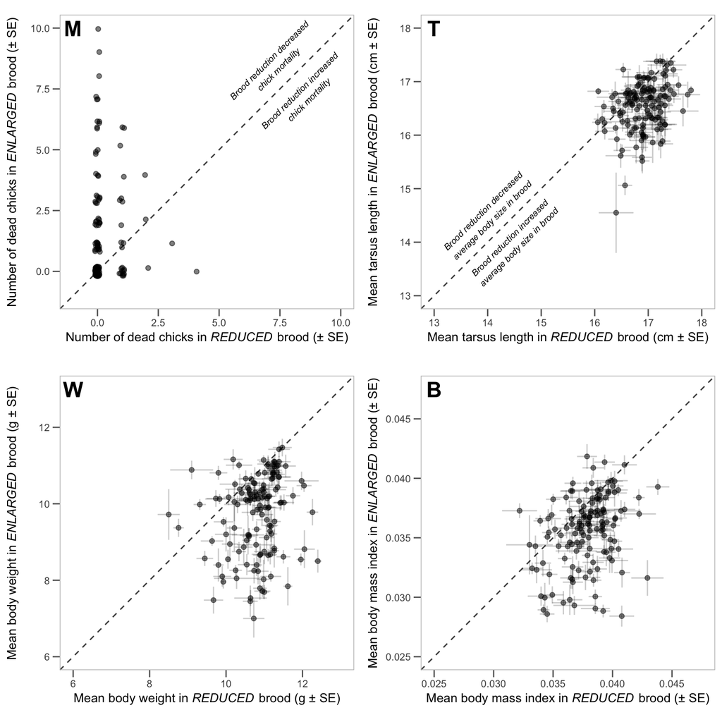

```r
mortality_plot <-
  ggplot(data = morphometric_summaries) +
  geom_abline(intercept = 0 , slope = 1, linetype = "dashed", color = "grey30") +
  # geom_point(aes(y = as.numeric(change_chick_n_increase), x = as.numeric(change_chick_n_decrease)), alpha = 0.5) +
  geom_jitter(aes(y = as.numeric(change_chick_n_increase), x = as.numeric(change_chick_n_decrease)),
              alpha = 0.5, width = 0.1, height = 0.2) +
  coord_fixed(ratio = 1) +
  xlab(expression(paste("Number of dead chicks in ", italic("REDUCED")," brood (± SE)"))) +
  ylab(expression(paste("Number of dead chicks in ", italic("ENLARGED")," brood (± SE)"))) +
  scale_y_continuous(limits = c(-1, 10)) +
  scale_x_continuous(limits = c(-1, 10)) +
  annotate(geom = "text", y = 7.25, x = 8.5, angle = 45,
           label = "Brood reduction increased\nchick mortality",
           color = "black", size = 2.5, fontface = 'italic') +
  annotate(geom = "text", y = 8.5, x = 7.25, angle = 45,
           label = "Brood reduction decreased\nchick mortality",
           color = "black", size = 2.5, fontface = 'italic') +
  annotate(geom = "text", y = 10, x = -1,
           label = "M",
           color = "black", size = 6, fontface = 'bold') +
  theme_bw() +
  theme(
    #text = element_text(family = "Franklin Gothic Book"),
    legend.title = element_text(size = 10),
    legend.text = element_text(size = 8),
    axis.title.x = element_text(size = 10),
    axis.text.x  = element_text(size = 8),
    axis.title.y = element_text(size = 10),
    axis.text.y = element_text(size = 8),
    panel.grid.major = element_blank(),
    panel.grid.minor = element_blank(),
    axis.ticks = element_line(size = 0.5, colour = "grey40"),
    axis.ticks.length = unit(0.2, "cm"),
    panel.border = element_rect(linetype = "solid", colour = "grey")
  )

tarsus_plot <-
  ggplot(data = morphometric_summaries) +
  geom_abline(intercept = 0 , slope = 1, linetype = "dashed", color = "grey30") +
  geom_point(aes(y = mean_tarsus_increase, x = mean_tarsus_decrease), alpha = 0.5) +
  geom_errorbar(aes(y = mean_tarsus_increase, x = mean_tarsus_decrease,
                    ymin = mean_tarsus_increase - se_tarsus_increase,
                    ymax = mean_tarsus_increase + se_tarsus_increase), alpha = 0.2) +
  geom_errorbarh(aes(y = mean_tarsus_increase, x = mean_tarsus_decrease,
                     xmin = mean_tarsus_decrease - se_tarsus_decrease,
                     xmax = mean_tarsus_decrease + se_tarsus_decrease), alpha = 0.2) +
  coord_fixed(ratio = 1) +
  xlab(expression(paste("Mean tarsus length in ", italic("REDUCED")," brood (cm ± SE)"))) +
  ylab(expression(paste("Mean tarsus length in ", italic("ENLARGED")," brood (cm ± SE)"))) +
  scale_y_continuous(limits = c(13, 18)) +
  scale_x_continuous(limits = c(13, 18)) +
  annotate(geom = "text", y = 14, x = 14.5, angle = 45,
           label = "Brood reduction increased\naverage body size in brood",
           color = "black", size = 2.5, fontface = 'italic') +
  annotate(geom = "text", y = 14.5, x = 14, angle = 45,
           label = "Brood reduction decreased\naverage body size in brood",
           color = "black", size = 2.5, fontface = 'italic') +
  annotate(geom = "text", y = 18, x = 13,
           label = "T",
           color = "black", size = 6, fontface = 'bold') +
  theme_bw() +
  theme(
    #text = element_text(family = "Franklin Gothic Book"),
    legend.title = element_text(size = 10),
    legend.text = element_text(size = 8),
    axis.title.x = element_text(size = 10),
    axis.text.x  = element_text(size = 8),
    axis.title.y = element_text(size = 10),
    axis.text.y = element_text(size = 8),
    panel.grid.major = element_blank(),
    panel.grid.minor = element_blank(),
    axis.ticks = element_line(size = 0.5, colour = "grey40"),
    axis.ticks.length = unit(0.2, "cm"),
    panel.border = element_rect(linetype = "solid", colour = "grey")
  )

mass_plot <-
  ggplot(data = morphometric_summaries) +
  geom_abline(intercept = 0 , slope = 1, linetype = "dashed", color = "grey30") +
  geom_point(aes(y = mean_mass_increase, x = mean_mass_decrease), alpha = 0.5) +
  geom_errorbar(aes(y = mean_mass_increase, x = mean_mass_decrease,
                    ymin = mean_mass_increase - se_mass_increase,
                    ymax = mean_mass_increase + se_mass_increase), alpha = 0.2) +
  geom_errorbarh(aes(y = mean_mass_increase, x = mean_mass_decrease,
                     xmin = mean_mass_decrease - se_mass_decrease,
                     xmax = mean_mass_decrease + se_mass_decrease), alpha = 0.2) +
  coord_fixed(ratio = 1) +
  xlab(expression(paste("Mean body weight in ", italic("REDUCED")," brood (g ± SE)"))) +
  ylab(expression(paste("Mean body weight in ", italic("ENLARGED")," brood (g ± SE)"))) +
  scale_y_continuous(limits = c(6, 13)) +
  scale_x_continuous(limits = c(6, 13)) +
  annotate(geom = "text", y = 13, x = 6,
           label = "W",
           color = "black", size = 6, fontface = 'bold') +
  theme_bw() +
  theme(
    #text = element_text(family = "Franklin Gothic Book"),
    legend.title = element_text(size = 10),
    legend.text = element_text(size = 8),
    axis.title.x = element_text(size = 10),
    axis.text.x  = element_text(size = 8),
    axis.title.y = element_text(size = 10),
    axis.text.y = element_text(size = 8),
    panel.grid.major = element_blank(),
    panel.grid.minor = element_blank(),
    axis.ticks = element_line(size = 0.5, colour = "grey40"),
    axis.ticks.length = unit(0.2, "cm"),
    panel.border = element_rect(linetype = "solid", colour = "grey")
  )

BMI_plot <-
  ggplot(data = morphometric_summaries) +
  geom_abline(intercept = 0 , slope = 1, linetype = "dashed", color = "grey30") +
  geom_point(aes(y = mean_BMI_increase, x = mean_BMI_decrease), alpha = 0.5) +
  geom_errorbar(aes(y = mean_BMI_increase, x = mean_BMI_decrease,
                    ymin = mean_BMI_increase - se_BMI_increase,
                    ymax = mean_BMI_increase + se_BMI_increase), alpha = 0.2) +
  geom_errorbarh(aes(y = mean_BMI_increase, x = mean_BMI_decrease,
                     xmin = mean_BMI_decrease - se_BMI_decrease,
                     xmax = mean_BMI_decrease + se_BMI_decrease), alpha = 0.2) +
  coord_fixed(ratio = 1) +
  xlab(expression(paste("Mean body mass index in ", italic("REDUCED")," brood (± SE)"))) +
  ylab(expression(paste("Mean body mass index in ", italic("ENLARGED")," brood (± SE)"))) +
  scale_y_continuous(limits = c(0.025, 0.0475)) +
  scale_x_continuous(limits = c(0.025, 0.0475)) +
  annotate(geom = "text", y = 0.0475, x = 0.025,
           label = "B",
           color = "black", size = 6, fontface = 'bold') +
  theme_bw() +
  theme(
   # text = element_text(family = "Franklin Gothic Book"),
    legend.title = element_text(size = 10),
    legend.text = element_text(size = 8),
    axis.title.x = element_text(size = 10),
    axis.text.x  = element_text(size = 8),
    axis.title.y = element_text(size = 10),
    axis.text.y = element_text(size = 8),
    panel.grid.major = element_blank(),
    panel.grid.minor = element_blank(),
    axis.ticks = element_line(size = 0.5, colour = "grey40"),
    axis.ticks.length = unit(0.2, "cm"),
    panel.border = element_rect(linetype = "solid", colour = "grey")
  )

ggarrange(mortality_plot,
          tarsus_plot,
          mass_plot,
          BMI_plot,
          ncol = 2, nrow = 2, align = "hv")
```

#### Figure EP | Differences in chick mortality and size within paired nests

Each point is a mean, the bars are standars errors (horizontal for the reduced brood, vertical for the enlarged brood) for each pair of nests that were experimentally controlled (“matched”) for hatch date and (partly) for brood size (see [Methods](https://raw.githack.com/MartinBulla/many_analysts/master/MS/Methods.html)). Dashed diagonal line represents no change in chick body morphometrics in response to the experimental brood enlargement or reduction. Points on the lower-right space of the plot show brood pairs in which chicks in the reduced treatment were larger than the increased treatment counterparts. Conversely, points in the upper-left space show brood pairs in which chicks in the enlarged treatment were larger than the reduced counterparts.

#### References

Gelman, Andrew, and Yu-Sung Su. 2018. “Arm: Data Analysis Using Regression and Multilevel/Hierarchical Models.” https://doi.org/http://CRAN.R-project.org/package=arm.